# Estudis d'Informàtica, Multimedia i Telecomunicacions

# Tipologia i cicle de vida de les dades: Pràctica 2. Heart Attack EDA

Autors: Antoni Espadas Navarro i Jordi Samaniego Vidal

Desembre 2022

En aquest document detallarem totes les anàlisis realitzades i els models construits en el marc de la segona pràctica de l’assignatura de Tipologia i Cicle de vida de les dades. En aquesta, utilitzarem el dataset que trobem al següent enllaç https://www.kaggle.com/datasets/rashikrahmanpritom/heart-attack-analysis-prediction-dataset, on tenim informació mèdica sobre diferents pacients i si aquests van patir un atac de cor o no.

# 1 Library

```r
if (!require('ggplot2')) install.packages('ggplot2'); library('ggplot2')
if (!require('dplyr')) install.packages('dplyr'); library('dplyr')
if (!require('tidyr')) install.packages('tidyr'); library('tidyr')
if (!require('reshape2')) install.packages('reshape2'); library('reshape2')
if (!require('corrplot')) install.packages('corrplot'); library('corrplot')
if (!require('randomForest')) install.packages('randomForest'); library('randomForest')
if (!require('rminer')) install.packages('rminer'); library('rminer')
if (!require('caret')) install.packages('caret'); library('caret')
if (!require('pROC')) install.packages('pROC'); library('pROC')
if(!require('gmodels')) install.packages('gmodels', repos='http://cran.us.r-project.org');library('gmodels')
```

# 2 Introducció

```r
heart <- read.csv("./dataset/heart.csv")
head(heart)
```

```
##   age sex cp trtbps chol fbs restecg thalachh exng oldpeak slp caa thall output
## 1  63   1  3    145  233   1       0      150    0     2.3   0   0     1      1
## 2  37   1  2    130  250   0       1      187    0     3.5   0   0     2      1
## 3  41   0  1    130  204   0       0      172    0     1.4   2   0     2      1
## 4  56   1  1    120  236   0       1      178    0     0.8   2   0     2      1
## 5  57   0  0    120  354   0       1      163    1     0.6   2   0     2      1
## 6  57   1  0    140  192   0       1      148    0     0.4   1   0     1      1
```

# 3 Descripció dels atributs

Un cop fet, mostrem quins atributs conté i la seva tipologia:

```r
str(heart)
```

```
## 'data.frame':    303 obs. of  14 variables:
##  $ age     : int  63 37 41 56 57 57 56 44 52 57 ...
##  $ sex     : int  1 1 0 1 0 1 0 1 1 1 ...
##  $ cp      : int  3 2 1 1 0 0 1 1 2 2 ...
##  $ trtbps  : int  145 130 130 120 120 140 140 120 172 150 ...
##  $ chol    : int  233 250 204 236 354 192 294 263 199 168 ...
##  $ fbs     : int  1 0 0 0 0 0 0 0 1 0 ...
##  $ restecg : int  0 1 0 1 1 1 0 1 1 1 ...
##  $ thalachh: int  150 187 172 178 163 148 153 173 162 174 ...
##  $ exng    : int  0 0 0 0 1 0 0 0 0 0 ...
##  $ oldpeak : num  2.3 3.5 1.4 0.8 0.6 0.4 1.3 0 0.5 1.6 ...
##  $ slp     : int  0 0 2 2 2 1 1 2 2 2 ...
##  $ caa     : int  0 0 0 0 0 0 0 0 0 0 ...
##  $ thall   : int  1 2 2 2 2 1 2 3 3 2 ...
##  $ output  : int  1 1 1 1 1 1 1 1 1 1 ...
```

Els atributs dels que disposem són:

Així doncs, tenim un total de 14 variables i 303 registres

```r
nrow(heart)
```

```
## [1] 303
```

Un cop tenim present a quina informació fa referència cada una de les variables del dataset, mostrarem el seu resum, per veure quins són els valors mínims i màxims de cada una de les variables numèriques:

```r
summary(heart)
```

```
##       age             sex               cp            trtbps
##  Min.   :29.00   Min.   :0.0000   Min.   :0.000   Min.   : 94.0
##  1st Qu.:47.50   1st Qu.:0.0000   1st Qu.:0.000   1st Qu.:120.0
##  Median :55.00   Median :1.0000   Median :1.000   Median :130.0
##  Mean   :54.37   Mean   :0.6832   Mean   :0.967   Mean   :131.6
##  3rd Qu.:61.00   3rd Qu.:1.0000   3rd Qu.:2.000   3rd Qu.:140.0
##  Max.   :77.00   Max.   :1.0000   Max.   :3.000   Max.   :200.0
##       chol            fbs            restecg          thalachh
##  Min.   :126.0   Min.   :0.0000   Min.   :0.0000   Min.   : 71.0
##  1st Qu.:211.0   1st Qu.:0.0000   1st Qu.:0.0000   1st Qu.:133.5
##  Median :240.0   Median :0.0000   Median :1.0000   Median :153.0
##  Mean   :246.3   Mean   :0.1485   Mean   :0.5281   Mean   :149.6
##  3rd Qu.:274.5   3rd Qu.:0.0000   3rd Qu.:1.0000   3rd Qu.:166.0
##  Max.   :564.0   Max.   :1.0000   Max.   :2.0000   Max.   :202.0
##       exng           oldpeak          slp             caa
##  Min.   :0.0000   Min.   :0.00   Min.   :0.000   Min.   :0.0000
##  1st Qu.:0.0000   1st Qu.:0.00   1st Qu.:1.000   1st Qu.:0.0000
##  Median :0.0000   Median :0.80   Median :1.000   Median :0.0000
##  Mean   :0.3267   Mean   :1.04   Mean   :1.399   Mean   :0.7294
##  3rd Qu.:1.0000   3rd Qu.:1.60   3rd Qu.:2.000   3rd Qu.:1.0000
##  Max.   :1.0000   Max.   :6.20   Max.   :2.000   Max.   :4.0000
##      thall           output
##  Min.   :0.000   Min.   :0.0000
##  1st Qu.:2.000   1st Qu.:0.0000
##  Median :2.000   Median :1.0000
##  Mean   :2.314   Mean   :0.5446
##  3rd Qu.:3.000   3rd Qu.:1.0000
##  Max.   :3.000   Max.   :1.0000
```

- Els pacients tenen entre 29 i 77 anys.
- La pressió arterial en repòs va entre 94 i 200.
- El nivell de colesterol va entre 126 i 564.
- La freqüència màxima aconseguida pels pacients va d’entre 71 i 202.
- L’old peak va des de 0 fins a 6,20.

# 4 Neteja de dades

Tot seguit, procedirem a analitzar aquells registres que continguin valors buits o outliers amb la finalitat de corregir-los i deixar el dataset net per a poder ser utilitzat posteriorment.

En primer lloc, mostrem quants valors buits (na) hi ha per a cada atribut:

```r
print("Count of missing values")
```

```
## [1] "Count of missing values"
```

```r
sapply(heart, function(x) sum(is.na(x)))
```

```
##      age      sex       cp   trtbps     chol      fbs  restecg thalachh
##        0        0        0        0        0        0        0        0
##     exng  oldpeak      slp      caa    thall   output
##        0        0        0        0        0        0
```

```r
blankValues <- heart == ""
colSums(blankValues)
```

```
##      age      sex       cp   trtbps     chol      fbs  restecg thalachh
##        0        0        0        0        0        0        0        0
##     exng  oldpeak      slp      caa    thall   output
##        0        0        0        0        0        0
```

No hi ha cap valor NA’s ni valors buits, en conseqüència, no hem de realitzar el procés d’eliminació de valors perduts. Haurem d’analitzar si hi ha una fila duplicada:

```r
sum(duplicated(heart))
```

```
## [1] 1
```

Actualitzem i ens quedem amb les files úniques:

```r
heart <- unique(heart)
dim(heart)
```

```
## [1] 302  14
```

Seguidament, procedirem a analitzar si hi ha valors extrems en les variables numèriques en les quals els possibles valors no estiguin acotats (com per exemple output, on només pot valdre 0 o 1).

Per a detectar outliers, mostrarem un gràfic de dispersió, el qual marcarà els possibles valors extrems i, a més, ens permetrà conèixer quina és la dispersió entre els diferents valors.

Mitjançant el següent gràfic mostrarem la distribució dels valors de cada columna:

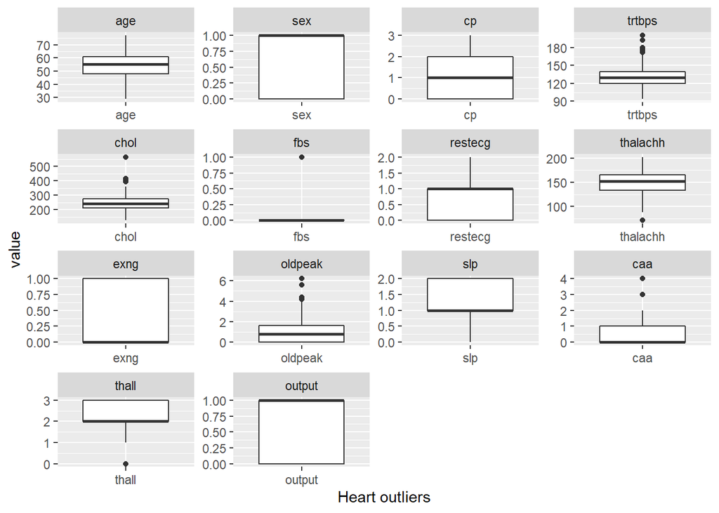

```r
meltData <- melt(heart)
plt <- ggplot(meltData, aes(factor(variable), value))
plt + geom_boxplot() + facet_wrap(~variable, scale="free") + labs(x = "Heart outliers", y = "value")
```

- Age: Observem que no hi ha outliers, la mitjana es troba als 55 anys i on trobem més registres és entre 47 i 62 anys.
- trtbps: Recordem que aquesta variable indica la pressió arterial en repòs. En aquest cas, es detecten alguns possibles valors extrems per sobre de 170. Tot i així, no ho considerarem com a outlier, doncs és possible que una persona tingui una pressió arterial de 200, tot i que pot ser un indicador de problemes mèdics de la persona.
- chol: En aquest cas, observem un registre que podriem considerar com a outlier, doncs un valor de 600 de colesterol és molt atípic. La resta de valors considerats com a extrems, no els considerarem outliers, doncs tot i que és un risc, un valor de 400 de colesterol pot ser correcte.

Per tant, eliminem els registres del dataset que tinguin un nivell de colesterol superior a 500:

```r
heart <- heart[heart$chol < 500, ]
```

- thalachh: Per a la freqüència cardíaca màxima no detectem outliers, doncs és normal que aquesta es trobi entre 90 i 200. Veiem un registre que té un valor proper a 75, tot i que ho considerarem correcte i no l’exclourem.

Finalment, procedirem a crear nous atributs al dataset a partir dels ja existents. En aquest cas, trobem que hi ha una sèrie de variables que tot i ser de tipus enter, el seu contingut és categòric. Per exemple, cp indica si el pacient sent algun dolor al pit, però els seus possibles valors no tenen cap ordre, sinó que cada enter indica un dolor al pit diferent. El mateix succeeix amb restecg

Així doncs, crearem dues variables noves, que tindran el mateix nom però amb el sufix “_cat”, que contindran aquestes variables trasformades a factors:

```r
heart$cp_cat <- cut(heart$cp, 4, labels=c('AnginaTipica', 'AnginaAtipica', 'SenseAngina', 'Asimptomatic'))
heart$restecg_cat <- cut(heart$restecg, 3, labels=c('Normal', 'WaveAbnormality', 'Hypertrophy'))
```

Per últim, i per facilitar les anàlisis posteriors, també transformarem a factor la variable sex:

```r
heart$sex_cat <- cut(heart$sex, 2, labels=c('F', 'M'))
```

Finalment, ho podem resumir en aquesta taula:

| Característiques | Definició | Tipus | Valor |
| --- | --- | --- | --- |
| age | Edat del pacient en anys | Enter | 29-77 |
| sex_cat | Gènere | Factor | (0) femení, (1) masculí |
| cp_cat | Tipus de dolor al pit | Factor | (0) angina típica, (1) angina atípica, (2) dolor no anginós, (3) asimptomàtic |
| trestbps | Pressió arterial en repòs en mmHg | Enter | 94-200 |
| chol | Colesterol sèric en mg/dl | Enter | 126-564 |
| fbs | Sucre en sang en dejú superior a 120 mg/dl | Enter | (0) Fals (1) Veritable |
| restecg_cat | Resultats electrocardiogràfics en repòs | Factor | (0)normal, (1)anormalitat de l’ona ST-T, (2)probable hipertròfia ventricular esquerre |
| thalachh | Freqüència cardíaca màxima aconseguida | Enter | 71 –202 |
| exang | Angina de pit induïda per l’exercici | Enter | (0)No(1)Sí |
| oldpeak | Depressió del ST induïda per l’exercici en relació amb el repòs | Numèric | 0-6,2 |
| slp | El pendent del segment ST de l’exercici màxim | Enter | 0-2 |
| caa | Nombre de vasos principals acolorits per fluorosopia | Enter | 0-4 |
| thall | Taxa de talassèmia | Enter | 0-3 |
| output | Diagnòstic de malalties del cor | Enter | (0) malaltia cardíaca no present, (1) malaltia cardíaca present |

## 4.1 EDA

Farem una breu exploració visual de les diferents columnes mostrades anteriorment. Subdividirem aquest apartat en dos grups de variables a analitzar: les categòriques i numèriques.

### 4.1.1 Variables categòriques

Dit això, podem extreure un primer insight del gènere i la variable target:

```r
female <- table(heart[heart$sex_cat=='F',]$output)
male <- table(heart[heart$sex_cat=='M',]$output)
combine <- rbind(female,male)
colnames(combine) <- c("No han patit atac de cor", "Han patit atac de cor")
rownames(combine) <- c("Dones", "Homes")
print(combine)
```

```
##       No han patit atac de cor Han patit atac de cor
## Dones                       24                    71
## Homes                      114                    92
```

Hi ha 71 dones de 95 que han diagnosticat malalties cardíaques i 92 homes de 206 van ser diagnosticats amb malaltia cardíaca. Això indica que el 75% de les dones d’aquest conjunt de dades tenen un diagnòstic de malaltia cardíaca, on només el 45% dels homes tenen un diagnòstic de malaltia cardíaca.

Visualtizem amb un mosaic la relació proporcional entre les dues variables anteriors:

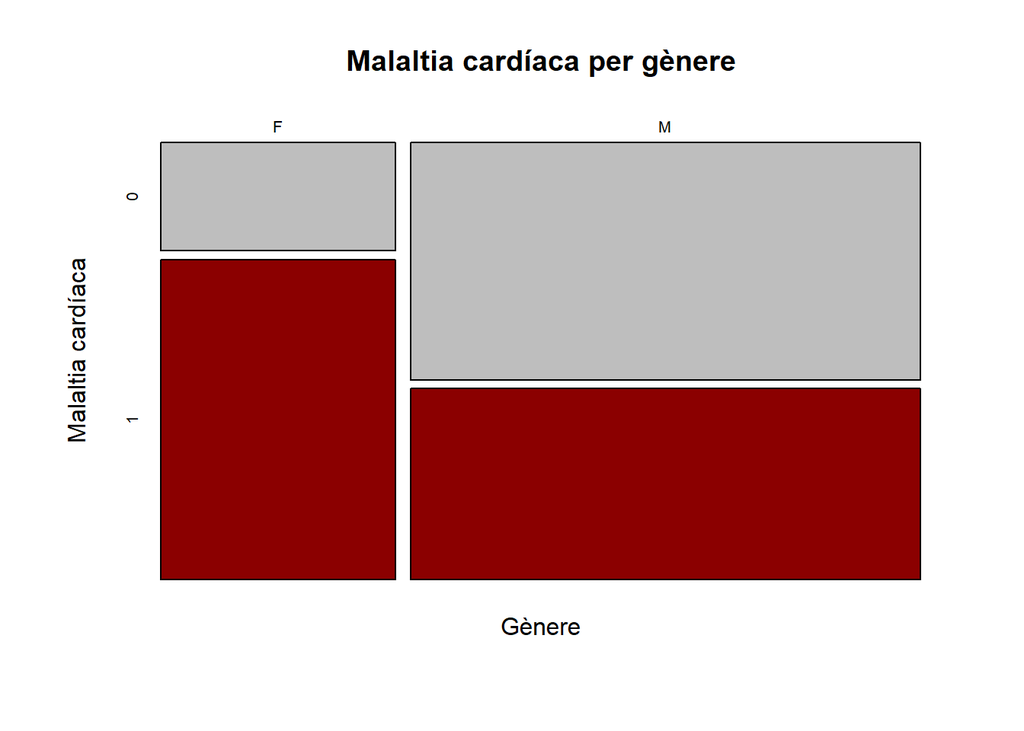

```r
mosaicplot(sex_cat ~ output, data = heart,
           main="Malaltia cardíaca per gènere", color = c("gray", "darkred"),
           xlab="Gènere", ylab="Malaltia cardíaca")
```

Observem que hi ha més proporció de malaltia cardíaca en les dones, com ja havíem avançat prèviament.

Analitzem la distribució de la columna del dolor de pit:

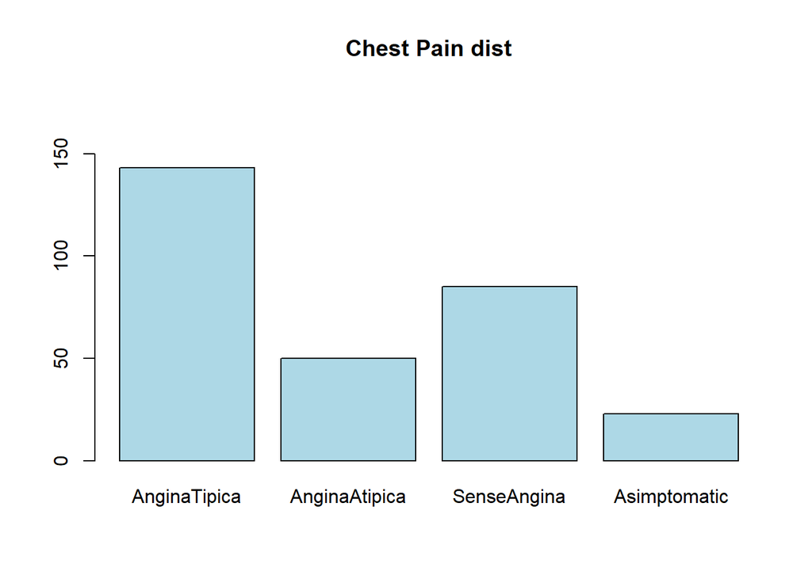

```r
ylim <- c(0, 1.25*max(table(heart$cp_cat)))
bar_cp <- barplot(table(heart$cp_cat), main="Chest Pain dist", col="lightblue", ylim = ylim)
```

Existeix més freqüència en angina típica que la resta.

Analitzem el diagnòstic de la malaltia cardíaca per Chest pain:

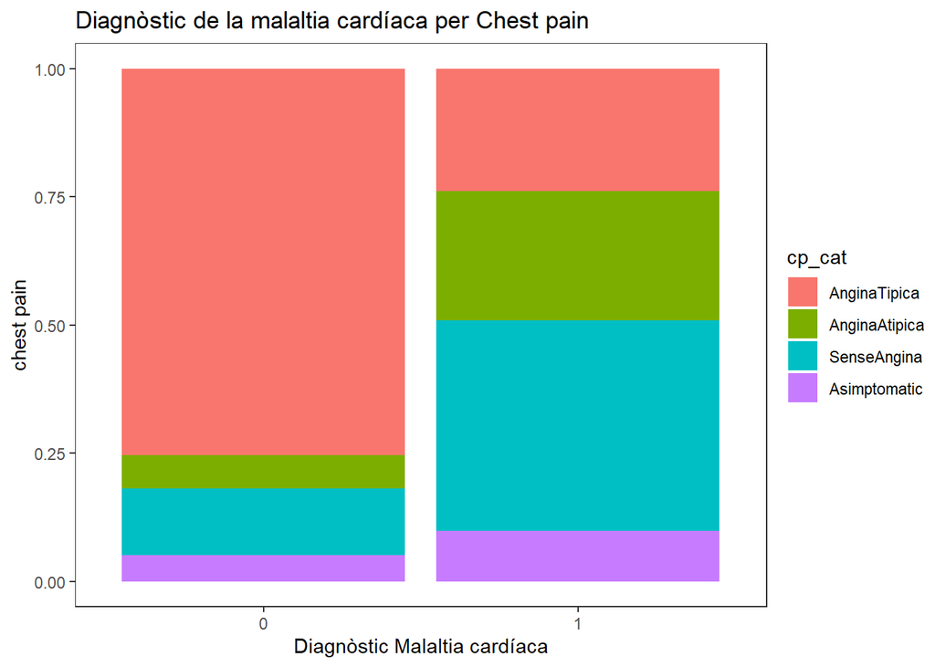

```r
ggplot(data = heart, aes(x = as.factor(output), fill = cp_cat)) +
  geom_bar(position = "fill") +
  labs(title = "Diagnòstic de la malaltia cardíaca per Chest pain",
       x = "Diagnòstic Malaltia cardíaca",
       y = "chest pain") +
  theme_test()
```

S’observa una reducció d’angina típica quan el registre correspon a un atac de cor

Analitzem la distribució del Resting Electrocardiographic:

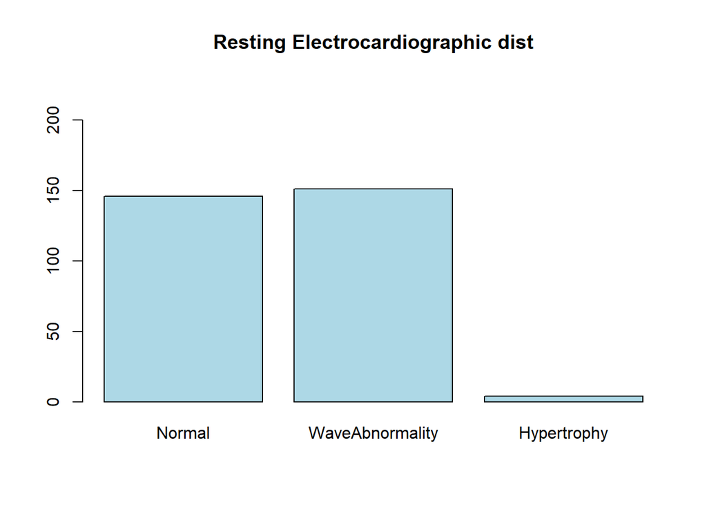

```r
ylim <- c(0, 1.5*max(table(heart$restecg_cat)))
bar_cp <- barplot(table(heart$restecg_cat), main="Resting Electrocardiographic dist", col="lightblue", ylim = ylim)
```

La distribució de freq en el valor de Hypertrophy és notablement inferior a la resta.

Analitzem el diagnòstic de la malaltia cardíaca per restecg:

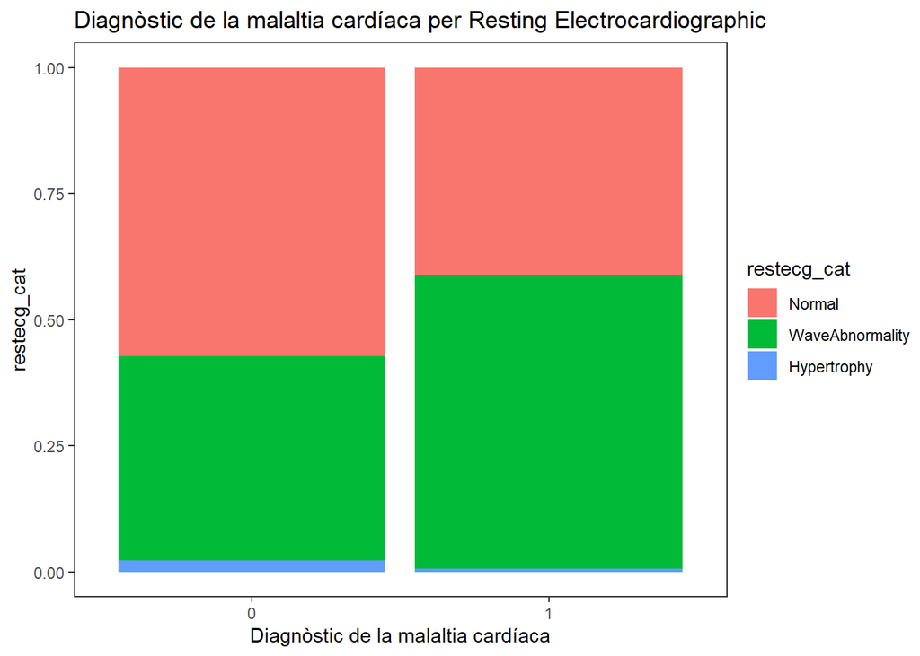

```r
ggplot(data = heart, aes(x = as.factor(output), fill = restecg_cat)) +
  geom_bar(position = "fill") +
  labs(title = "Diagnòstic de la malaltia cardíaca per Resting Electrocardiographic",
       x = "Diagnòstic de la malaltia cardíaca",
       y = "restecg_cat") +
  theme_test()
```

Hi ha una lleugera pujada d’onada arrítmica quan es tracta d’un infart respecte d’aquells que no.

Analitzem la freqüència del nivell de sucre en sang en dejú:

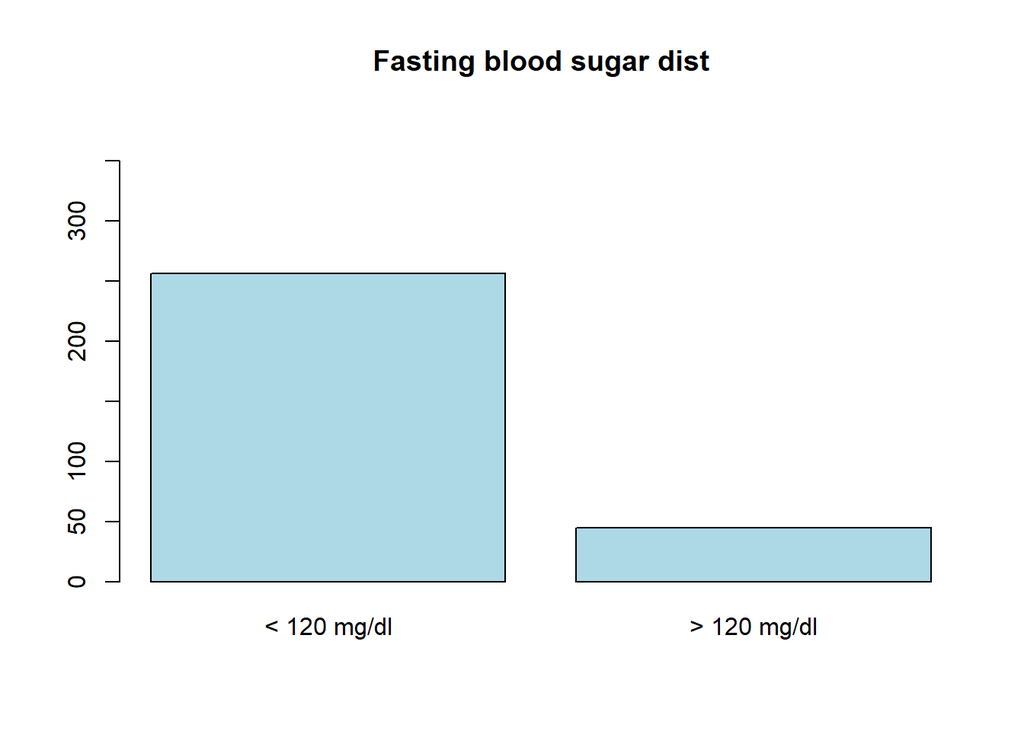

```r
ylim <- c(0, 1.5*max(table(as.factor(heart$fbs))))
bar_cp <- barplot(table(as.factor(heart$fbs)), main="Fasting blood sugar dist", col="lightblue", ylim = ylim, names = c('< 120 mg/dl', '> 120 mg/dl'))
```

Hi ha una major freqüència de registres amb < 120 mg/dk.

Analitzem el diagnòstic de la malaltia cardíaca per FBS:

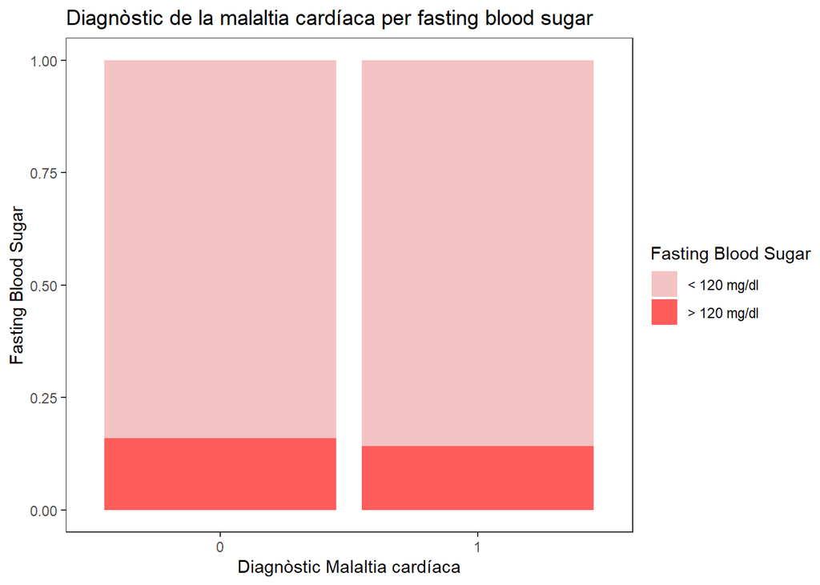

```r
ggplot(data = heart, aes(x = as.factor(output), fill = as.factor(fbs))) +
  geom_bar(position = "fill") +
  labs(title = "Diagnòstic de la malaltia cardíaca per fasting blood sugar",
       x = "Diagnòstic Malaltia cardíaca",
       y = "Fasting Blood Sugar") +
  scale_fill_manual(values=c("#F4C2C2", '#FF5C5C'),
                       name="Fasting Blood Sugar",
                       labels=c('< 120 mg/dl', '> 120 mg/dl'))+
  theme_test()
```

No hi ha diferències significatives per la malaltia en vers al nivell de sucre en sang.

Analitzem la distribució de l’angina induïda per l’exercici:

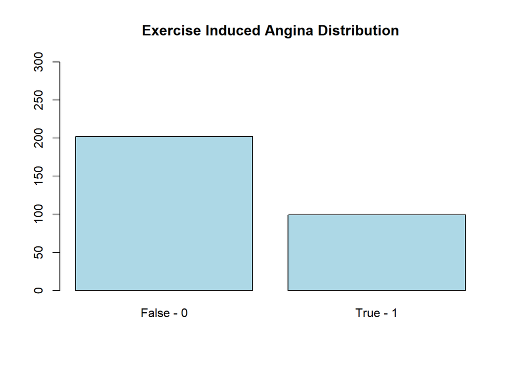

```r
ylim <- c(0, 1.5*max(table(as.factor(heart$exng))))
bar_cp <- barplot(table(as.factor(heart$exng)), main="Exercise Induced Angina Distribution", col="lightblue", ylim = ylim, names = c('False - 0', 'True - 1'))
```

Analitzem el diagnòstic de la malaltia cardíaca per exng:

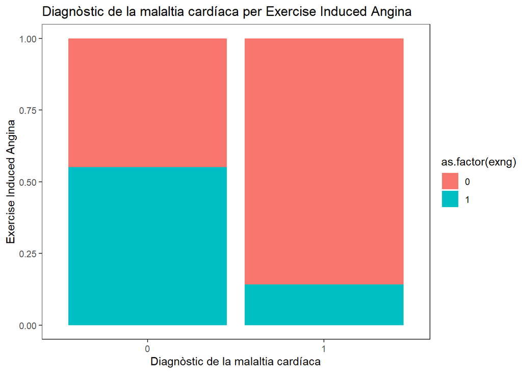

```r
ggplot(data = heart, aes(x = as.factor(output), fill = as.factor(exng))) +
  geom_bar(position = "fill") +
  labs(title = "Diagnòstic de la malaltia cardíaca per Exercise Induced Angina",
       x = "Diagnòstic de la malaltia cardíaca",
       y = "Exercise Induced Angina") +
  theme_test()
```

La majoria de casos en el que hi ha la malaltia no hi ha presència d’angina de pit induïda per l’exercici, en canvi, quan no hi ha presència de malaltia es mostra un equilibri d’aquesta.

Analitzem el desplaçament del segment ST en relació amb els increments de la freqüència cardíaca induïts per l’exercici:

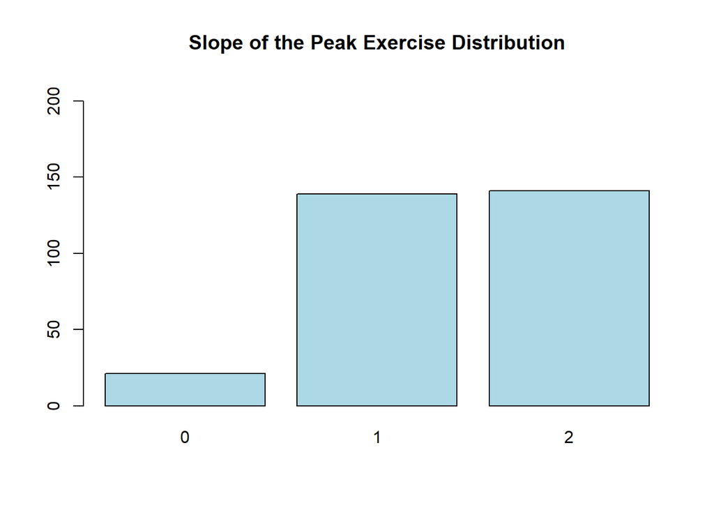

```r
ylim <- c(0, 1.5*max(table(as.factor(heart$slp))))
bar_cp <- barplot(table(as.factor(heart$slp)), main="Slope of the Peak Exercise Distribution", col="lightblue", ylim = ylim)
```

Predomina el valor 1 i 2.

Ara, analitzem com es distribueixen els valors d’slp en funció de si correspon a un pacient amb atac de cor o no.

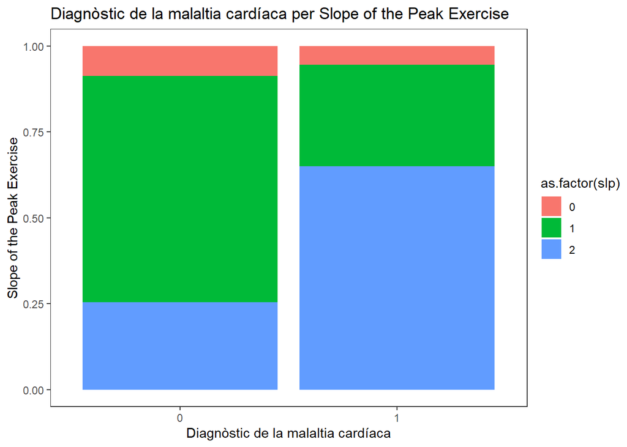

```r
ggplot(data = heart, aes(x = as.factor(output), fill = as.factor(slp))) +
  geom_bar(position = "fill") +
  labs(title = "Diagnòstic de la malaltia cardíaca per Slope of the Peak Exercise",
       x = "Diagnòstic de la malaltia cardíaca",
       y = "Slope of the Peak Exercise") +
  theme_test()
```

En cas de malaltia, predomina el valor 2, en cas contrari, predomina el valor 1

Analitzem la distribució del nombre de vasos principals:

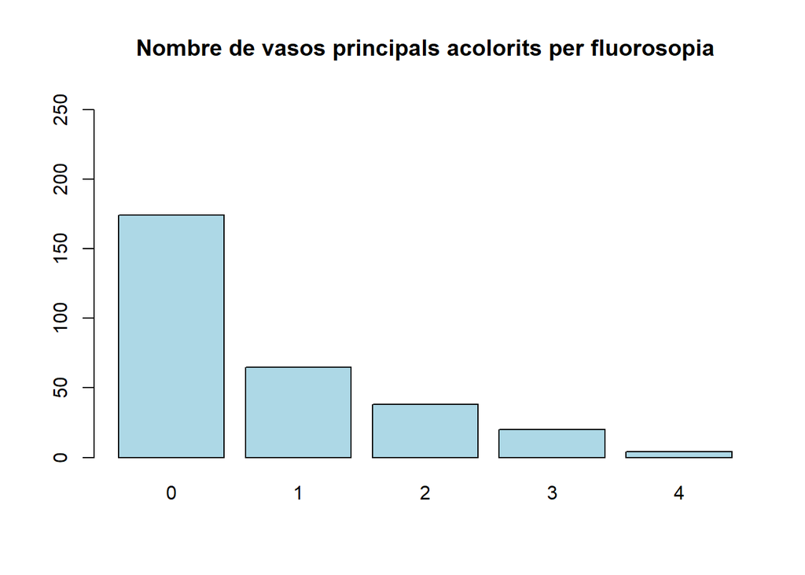

```r
ylim <- c(0, 1.5*max(table(as.factor(heart$caa))))
bar_cp <- barplot(table(as.factor(heart$caa)), main="Nombre de vasos principals acolorits per fluorosopia", col="lightblue", ylim = ylim)
```

El número 0 és el predominant i els següents van disminuint la seva representació de forma gradual.

Analitzem el diagnòstic de la malaltia cardíaca per caa:

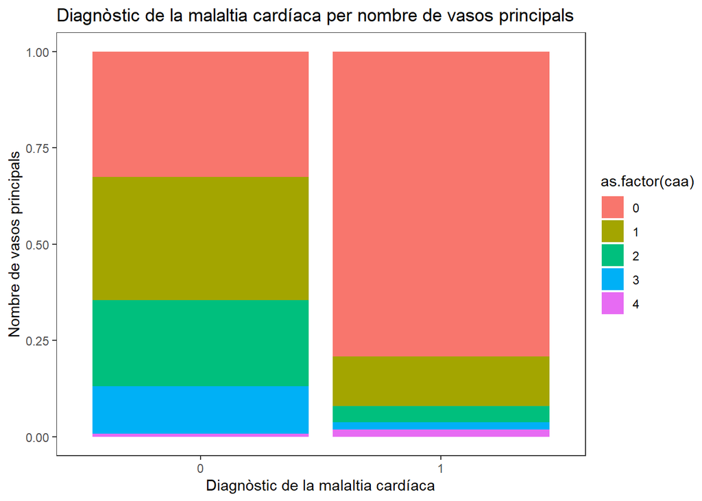

```r
ggplot(data = heart, aes(x = as.factor(output), fill = as.factor(caa))) +
  geom_bar(position = "fill") +
  labs(title = "Diagnòstic de la malaltia cardíaca per nombre de vasos principals",
       x = "Diagnòstic de la malaltia cardíaca",
       y = "Nombre de vasos principals") +
  theme_test()
```

En cas de malaltia, predomina el número 0, en cas contrari, hi ha una equilibri relatiu.

Analitzem la columna ‘thall’:

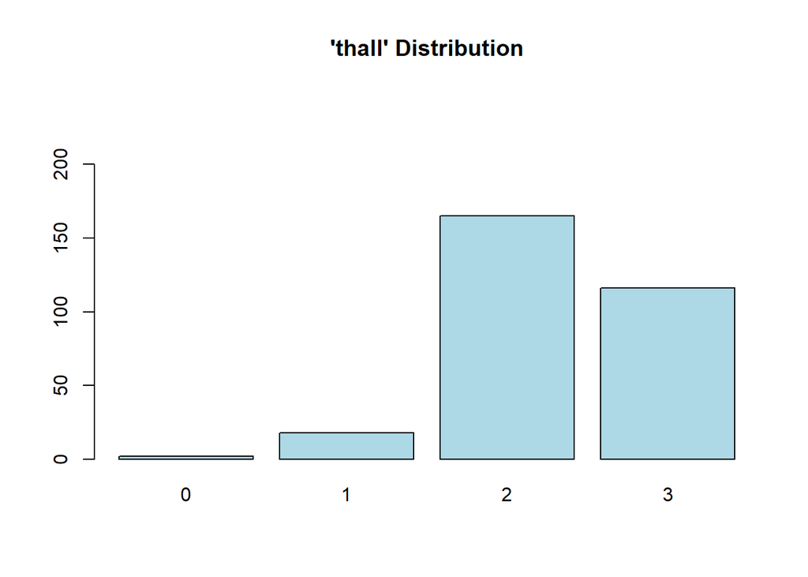

```r
ylim <- c(0, 1.5*max(table(as.factor(heart$thall))))
bar_cp <- barplot(table(as.factor(heart$thall)), main="'thall' Distribution", col="lightblue", ylim = ylim)
```

Trobem una baixa representació del número 0. Predomina el valor 2 seguit del 3.

Analitzem el diagnòstic de la malaltia cardíaca per thall.

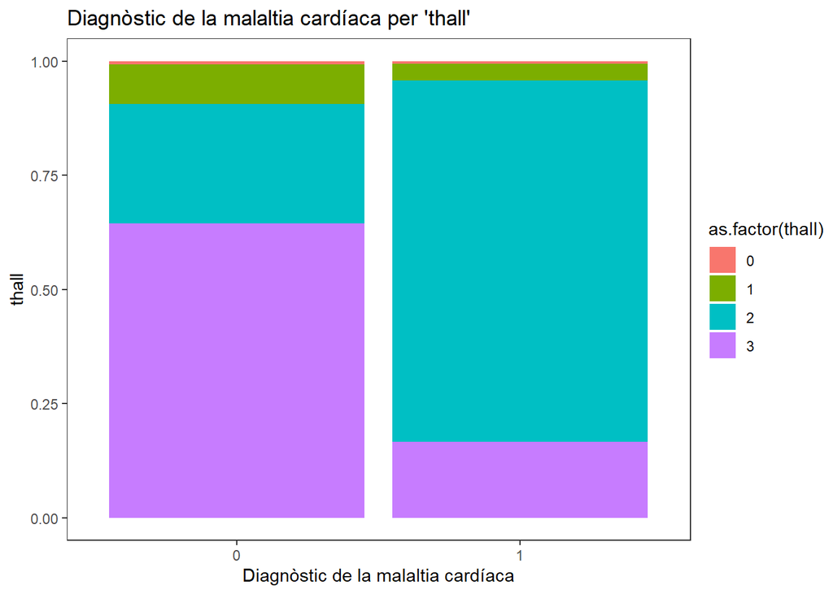

```r
ggplot(data = heart, aes(x = as.factor(output), fill = as.factor(thall))) +
  geom_bar(position = "fill") +
  labs(title = "Diagnòstic de la malaltia cardíaca per 'thall'",
       x = "Diagnòstic de la malaltia cardíaca",
       y = "thall") +
  theme_test()
```

Extraiem un insight molt representatiu: aquells que pateixen la malaltia predomina el valor 2 de “thall”, en canvi, d’aquells que no, predomina el valor 3.

Per finalitzar aquesta secció:

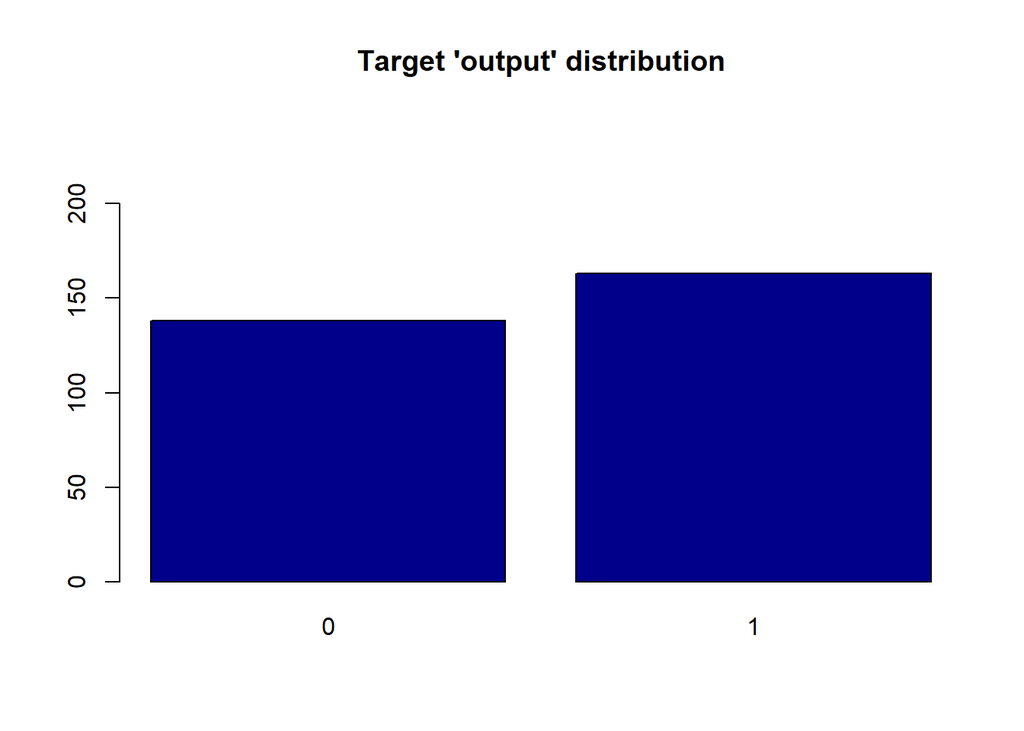

```r
ylim <- c(0, 1.5*max(table(as.factor(heart$output))))
bar_cp <- barplot(table(as.factor(heart$output)), main="Target 'output' distribution", col="darkblue", ylim = ylim)
```

La columna objectiu ‘output’ està força equilibrada.

### 4.1.2 Variables numèriques

Aquesta secció mostrarà la distribució i densitat de variables numèriques en histogrames:

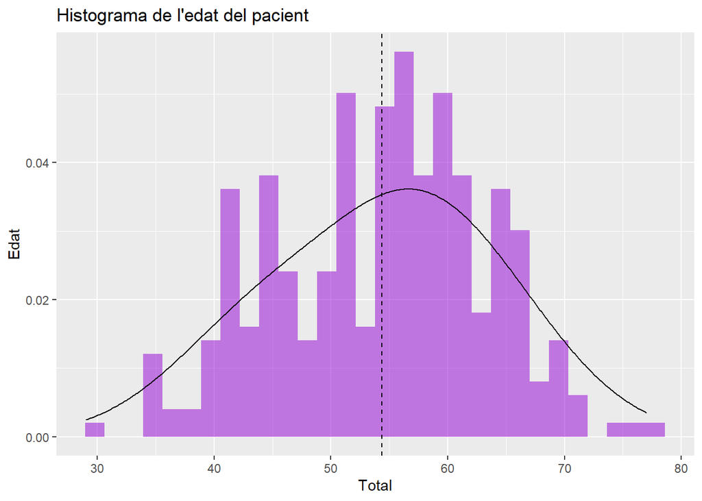

```r
ggplot(heart, aes(x=age, y =..density..)) +
  geom_histogram(alpha=0.5, position="identity", bins = 30, fill  = "darkviolet")+
  geom_vline(aes(xintercept = mean(age)), linetype="dashed")+
  labs(title="Histograma de l'edat del pacient",
       x="Total", y="Edat")+
  geom_density(alpha=0.6, adjust = 2.25)
```

Força simètric, amb tendència a tenir asimteria negativa.

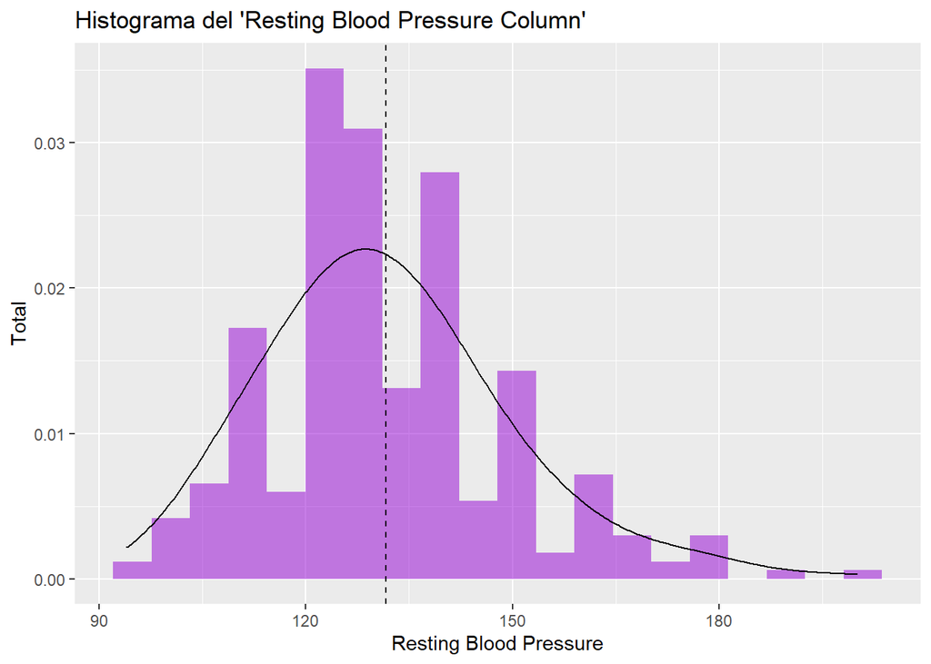

```r
ggplot(heart, aes(x=trtbps, y =..density..)) +
  geom_histogram(alpha=0.5, position="identity", bins = 20, fill  = "darkviolet")+
  geom_vline(aes(xintercept = mean(trtbps)), linetype="dashed")+
  labs(title="Histograma del 'Resting Blood Pressure Column'",
       x="Resting Blood Pressure", y="Total")+
  geom_density(alpha=0.6, adjust = 1.75)
```

També presenta una distribució força simètrica.

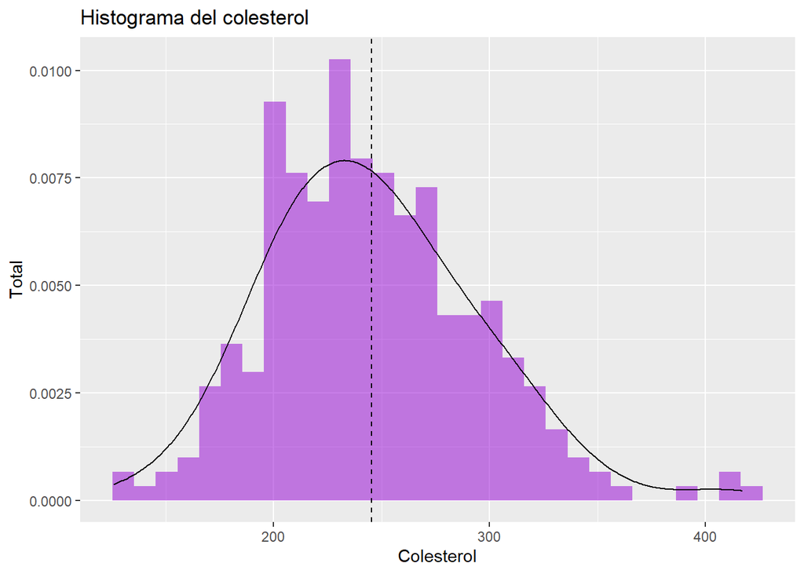

```r
ggplot(heart, aes(x=chol, y =..density..)) +
  geom_histogram(alpha=0.5, position="identity", bins = 30, fill  = "darkviolet")+
  geom_vline(aes(xintercept = mean(chol)), linetype="dashed")+
  labs(title="Histograma del colesterol",
       x="Colesterol", y="Total")+
  geom_density(alpha=0.6, adjust = 1.5)
```

Simètric, però amb tendència a tenir asimetria positiva.

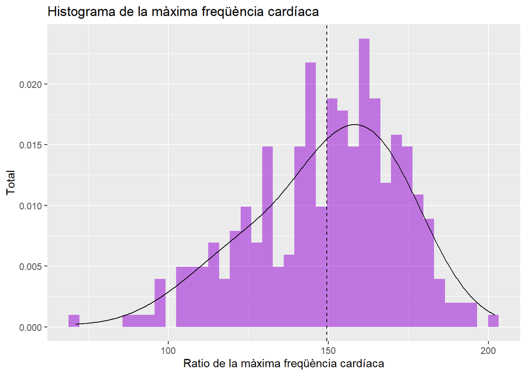

```r
ggplot(heart, aes(x=thalachh, y =..density..)) +
  geom_histogram(alpha=0.5, position="identity", bins = 40, fill  = "darkviolet")+
  geom_vline(aes(xintercept = mean(thalachh)), linetype="dashed")+
  labs(title="Histograma de la màxima freqüència cardíaca",
       x="Ratio de la màxima freqüència cardíaca", y="Total")+
  geom_density(alpha=0.6, adjust = 1.5)
```

Presenta asimetria negativa.

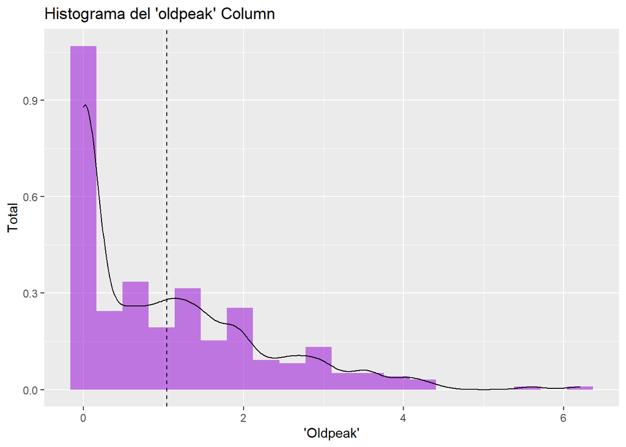

```r
ggplot(heart, aes(x=oldpeak, y =..density..)) +
  geom_histogram(alpha=0.5, position="identity", bins = 20, fill  = "darkviolet")+
  geom_vline(aes(xintercept = mean(oldpeak)),linetype="dashed")+
  labs(title="Histograma del 'oldpeak' Column",
       x="'Oldpeak'", y="Total")+
  geom_density(alpha=0.6, adjust = 0.5)
```

Distribució asimètrica totalment positiva. La majoria de registres es concentren en valors entre 0 i 1.

# 5 Models generats

Ara, procedirem a realitzar diferents anàlisis i crear diferents models per predir informació relacionada amb el dataset.

Per una banda, realitzarem un contrast de mitjanes per tal de saber si hi ha diferències entre la possibilitat d’un atac de cor entre homes i dones.

També, analitzarem les correlacions entre els diferents atributs del dataset “heart” del que disposem.

Per últim, crearem dos models supervisats, un de regressió logística i l’altre un Random Forest, per tal de predir les possibilitats d’atac de cor d’un pacient.

## 5.1 Anàlisi de la normalitat i homogeneïtat de la variància

En primer lloc, abans d’aplicar cap model, és necessari conèixer si el conjunt de dades segueix una distribució normal i si presenta homoscedasticitat, doncs en base a axiò, podrem aplicar uns models o uns altres.

Així doncs, començarem amb l’anàlisi de normalitat. Cal tenir present, però, que la variable dependent que volem predir (output) es tracta d’un atribut binari, és a dir, només pot prendre dos possibles valors. Per tant, la distribució d’una variable dicotòmica mai podrà presentar una distribució normal.

Tot i així, apliquem el test de Kolmogorov-Smirnov sota la hipòtesi nul·la de que les dades són normals. També aplicarem el test de Shapiro-Wilk.

```r
ks.test(heart$output, pnorm, mean(heart$output), sd(heart$output))
```

```
##
##  Asymptotic one-sample Kolmogorov-Smirnov test
##
## data:  heart$output
## D = 0.36237, p-value < 2.2e-16
## alternative hypothesis: two-sided
```

```r
shapiro.test(heart$output)
```

```
##
##  Shapiro-Wilk normality test
##
## data:  heart$output
## W = 0.63397, p-value < 2.2e-16
```

Observem que obtenim un p-valor de quasi zero pels dos tests, fet que ens permet rebutjar la hipòtesi nul·la. Per tant, podem dir que les dades no presenten normalitat.

Tot i així, en tenir un conjunt significativament gran (més de 30 registres) pel Teorema del Límit central podem suposar que la mitjana de les dades sí que presenta normalitat.

Per altra banda, procedim a analitzar si el conjunt presenta homoscedasticitat, és a dir, igualtat de variància. Per a fer-ho, utilitzarem la funció var.test(). Aquest test l’aplicarem per saber si la variable output presenta igualtat de variàncies o no entre homes i dones.

Apliquem el test sota la hipòtesi nul·la d’igualtat de variàncies:

```r
var.test( heart$output[heart$sex_cat=="F"], heart$output[heart$sex_cat=="M"] )
```

```
##
##  F test to compare two variances
##
## data:  heart$output[heart$sex_cat == "F"] and heart$output[heart$sex_cat == "M"]
## F = 0.76833, num df = 94, denom df = 205, p-value = 0.1482
## alternative hypothesis: true ratio of variances is not equal to 1
## 95 percent confidence interval:
##  0.5492551 1.0993475
## sample estimates:
## ratio of variances
##          0.7683278
```

Obtenim un p-valor de 0.15, fet que no ens permet rebutjar la hipòtesi de igualtat de variàncies. Per tant, podem dir que la probabilitat d’un atac de cor entre homes i dones presenta igualtat de variàncies.

## 5.2 Anàlisi de correlacions

En aquesta secció, procedirem a analitzar quines correlacions presenten els diferents atributs.

Utilitzarem només els atributs de tipus numèric:

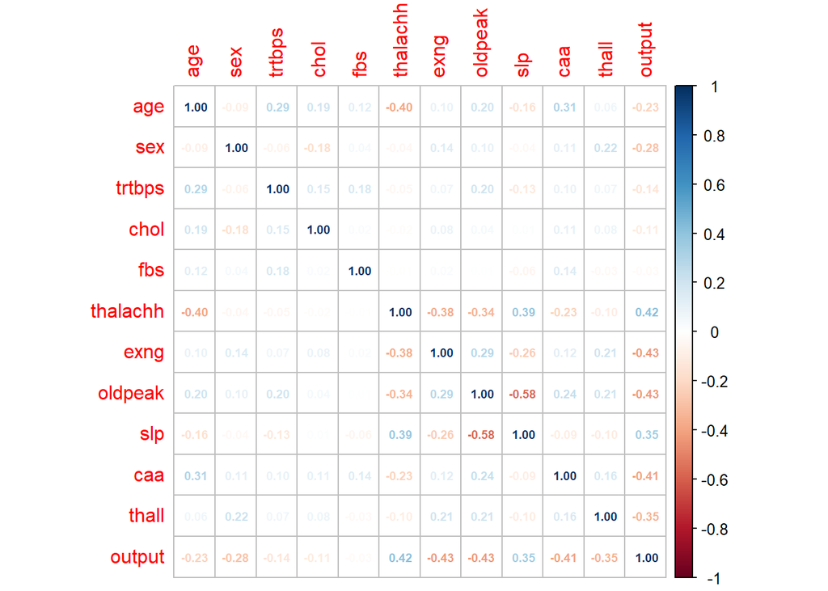

```r
mat <- cor(heart[,c("age", "sex",  "trtbps","chol","fbs","thalachh","exng","oldpeak","slp","caa","thall", "output")])

corrplot(mat, method = 'number', number.digits = 2, addCoef.col = 15,number.cex = 0.6) # colorful number
```

Del gràfic obtingut cal interpretar el següent: si el nombre és positiu i proper a 1, les dues variables presenten correlació positiva, és a dir, les dues variables augmenten alhora En canvi, si el valor és negatiu i proper a -1, les dues variables presenten correlació negativa, és a dir, quan una augmenta l’altra disminueix. Per últim, si el valor és proper a zero significa que les variables no presenten correlació.

Si ens fixem en les correlacions respecte Output:

- La variable que més correlació positiva presenta és thalach, es a dir, com més freqüència cardíaca màxima presenta el pacient, més probabilitat d’atac de cor.
- La variable exng presenta una correlació negativa. És a dir, hi ha correlació entre no tenir angina en fer esport i patir un atac de cor.
- La variable caa presenta correlació negativa. Hi ha correlació entre un nombre baix de vasos cardíacs principals i patir un atac de cor.
- La variable oldpeak presenta correlació negativa. Hi ha correlació entre una baixa depressió del ST induïda per l’exercici en relació amb el repòs i patir un atac de cor.

Tot i així, ens fixem que en valor absolut, cap correlació presenta un valor superior a 0,5. Això vol dir, que realment tenim un nivell bastant baix de correlació entre les variables i el succés output.

## 5.3 Contrast de mitjanes

Ara, aplicarem un contrast de mitjanes per saber si hi ha diferències entre les possibilitats d’un atac de cor entre homes i dones.

En aquest cas, utilitzarem les següents hipòtesis nul·la i alternativa:

Hipòtesi nul·la: l’output entre homes i dones és igual.

$H_0 : Output_{homes} = Output_{dones}$

Hipòtesi alternativa: l’output entre homes i dones és diferent.

$H_1 : Output_{homes} \neq Output_{dones}$

Per aplicar el contrast, cal recordar les dues conclusions extretes prèviament: es tracta d’una distribució normal (TLC) amb variàncies desconegudes i iguals. Així doncs, podrem aplicar una prova de contrast d’hipòtesi de tipus paramètric, com la t d’student.

Per tant, aplicarem la funció t.test():

```r
contrast_mitjanes <- t.test( heart$output[heart$sex_cat=="F"], heart$output[heart$sex_cat=="M"],alternative="two.sided", var.equal=TRUE)
contrast_mitjanes
```

```
##
##  Two Sample t-test
##
## data:  heart$output[heart$sex_cat == "F"] and heart$output[heart$sex_cat == "M"]
## t = 5.0539, df = 299, p-value = 7.553e-07
## alternative hypothesis: true difference in means is not equal to 0
## 95 percent confidence interval:
##  0.1836516 0.4178814
## sample estimates:
## mean of x mean of y
## 0.7473684 0.4466019
```

Obtenim un p-valor de pràcticament zero, fet que ens permet rebutjar la hipòtesi nul·la. Per tant, amb un nivell de confiança superior al 99%, podem dir que hi ha diferències entre la possiblitat d’un atac de cor entre homes i dones.

## 5.4 Model de regressió logística

Donat que la variable a predir (output) conté una informació binària (1 = propens a patir un atac de cor; 0 = no propens a patir un atac de cor), el primer model que crearem serà una regressió logística, la qual permet predir una variable dicotòmica.

Abans, però, crearem subconjunts d’entrenament i test que ens serviran per entrenar i avaluar el model.

### 5.4.1 Cració dels sets d’entrenament i test

Així doncs, generem un set de dades d’entrenament, el qual contindrà el 80% dels registres, i un set de test, per a validar els models construits a partir de les dades d’entrenament.

Considerem que és important, però, que la variable a predir, es trobi en la mateixa proporció entre el dataset d’entrenament i de test, per tal de no obtenir un model esbiaixat. Per a fer-ho, utilitzarem la funció createDataPartition (de la llibreria caret), la qual permet assegurar que, en fer les particions, tinguem la mateixa proporció de la variable objectiu en ambdos datasets.

Així doncs, executarem la funció esmentada, passant com a paràmetre output (variable que volem predir), i una proporció de 0.8, doncs volem que el conjunt d’entrenament contingui el 80% dels registres. La funció retornarà uns índexos, amb els quals crearem els sets d’entrenament i test:

```r
set.seed(123)

trainIndex <- createDataPartition(heart$output, p = .8,
                                  list = FALSE,
                                  times = 1)
train <- heart[ trainIndex,]
test <- heart[-trainIndex,]
```

Un cop feta la creació dels dos nous conjunts, validarem que, efectivament el d’entrenament contingui el 80% dels registres, i que els dos tinguin la mateixa proporció de registres amb valor d’opuput = 1:

```r
cat(paste("El set d'entrenament té ", toString(nrow(train)), "registres, i el de test ", toString(nrow(test)),". Per tant, el d'entrenament conté el ", toString(100 * nrow(train)/(nrow(train) + nrow(test))) , "% dels registres."))
```

```
## El set d'entrenament té  241 registres, i el de test  60 . Per tant, el d'entrenament conté el  80.0664451827243 % dels registres.
```

```r
cat(paste("\nEl set d'entrenament té ", toString(nrow(train[train$output == 1,])), "registres amb valor output = 1 i ", toString(nrow(train[train$output == 0,]))," amb output = 0. Per tant, el dataset d'entrenament conté un ", toString(100 * nrow(train[train$output == 1,])/(nrow(train[train$output == 1,]) + nrow(train[train$output == 0,]))) , "% de pacients que han patit un atac de cor."))
```

```
##
## El set d'entrenament té  131 registres amb valor output = 1 i  110  amb output = 0. Per tant, el dataset d'entrenament conté un  54.356846473029 % de pacients que han patit un atac de cor.
```

```r
cat(paste("\nEl set de test té ", toString(nrow(test[test$output == 1,])), "registres amb valor output = 1 i ", toString(nrow(test[test$output == 0,]))," amb output = 0. Per tant, el dataset d'entrenament conté un ", toString(100 * nrow(test[test$output == 1,])/(nrow(test[test$output == 1,]) + nrow(test[test$output == 0,]))) , "% de pacients que han patit un atac de cor"))
```

```
##
## El set de test té  32 registres amb valor output = 1 i  28  amb output = 0. Per tant, el dataset d'entrenament conté un  53.3333333333333 % de pacients que han patit un atac de cor
```

### 5.4.2 Implementació del model

Pel model de regressió logística, en primera instància, inclourem totes les variables independents possibles, per tal de poder analitzar si totes elles són significatives o no. Així doncs, generem el model_glm_1 i en mostrem el seu summary:

```r
model_glm_1 <- glm(output~age+sex_cat+cp_cat+trtbps+chol+fbs+restecg_cat+thalachh+exng+oldpeak+slp+caa+thall, data=train, family = binomial)
summary(model_glm_1)
```

```
##
## Call:
## glm(formula = output ~ age + sex_cat + cp_cat + trtbps + chol +
##     fbs + restecg_cat + thalachh + exng + oldpeak + slp + caa +
##     thall, family = binomial, data = train)
##
## Deviance Residuals:
##     Min       1Q   Median       3Q      Max
## -2.6108  -0.3097   0.1651   0.5210   2.6692
##
## Coefficients:
##                             Estimate Std. Error z value Pr(>|z|)
## (Intercept)                 3.770862   2.936101   1.284 0.199034
## age                        -0.003891   0.027543  -0.141 0.887663
## sex_catM                   -1.790184   0.538075  -3.327 0.000878 ***
## cp_catAnginaAtipica         0.717248   0.648487   1.106 0.268712
## cp_catSenseAngina           1.572284   0.535950   2.934 0.003350 **
## cp_catAsimptomatic          1.580715   0.696481   2.270 0.023233 *
## trtbps                     -0.025854   0.012577  -2.056 0.039809 *
## chol                       -0.004151   0.004821  -0.861 0.389304
## fbs                         0.696883   0.607743   1.147 0.251516
## restecg_catWaveAbnormality  0.674691   0.426458   1.582 0.113631
## restecg_catHypertrophy      0.233133   2.215518   0.105 0.916195
## thalachh                    0.029285   0.012064   2.427 0.015204 *
## exng                       -0.988470   0.478457  -2.066 0.038833 *
## oldpeak                    -0.564770   0.256731  -2.200 0.027817 *
## slp                         0.345321   0.414594   0.833 0.404893
## caa                        -0.776810   0.238856  -3.252 0.001145 **
## thall                      -1.005681   0.388177  -2.591 0.009576 **
## ---
## Signif. codes:  0 '***' 0.001 '**' 0.01 '*' 0.05 '.' 0.1 ' ' 1
##
## (Dispersion parameter for binomial family taken to be 1)
##
##     Null deviance: 332.26  on 240  degrees of freedom
## Residual deviance: 159.47  on 224  degrees of freedom
## AIC: 193.47
##
## Number of Fisher Scoring iterations: 6
```

Del resultat obtingut, primerament ens centrem en el p-valor de cada variable. Si aquest supera 0.05, podrem dir amb un 95% de confiança que la variable no és significativa. Recordem que una variable no-significativa és aquella que no té cap afectació sobre la variable dependent, generant per aquest atribut una recta de pendent zero que no aporta cap informació en el model .

Així doncs, aquestes variables són candidates a ser excloses del model final.

Tot seguit, procedim a analitzar les Odds-Ratio de cada variable, les quals poden prendre els següent valors:

Odd-Ratio proper a 1: Indica que no hi ha relació entre la covariable i la variable dependent (output).

Odd-Ratio superior a 1: Es tracta d’un factor de risc, doncs si aquesta covariable està present, el succés (és adir, que el pacient pateixi un atac de cor) és més probable.

Odd-Ratio inferior a 1: Es tracta d’un factor de protecció, doncs si aquesta covariable està present, el succés serà menys probable.

Per a calcular les Odd-Ratio utilitzem la funció coef():

```r
exp(coef(model_glm_1))
```

```
##                (Intercept)                        age
##                 43.4174922                  0.9961168
##                   sex_catM        cp_catAnginaAtipica
##                  0.1669295                  2.0487880
##          cp_catSenseAngina         cp_catAsimptomatic
##                  4.8176386                  4.8584293
##                     trtbps                       chol
##                  0.9744773                  0.9958580
##                        fbs restecg_catWaveAbnormality
##                  2.0074852                  1.9634265
##     restecg_catHypertrophy                   thalachh
##                  1.2625494                  1.0297176
##                       exng                    oldpeak
##                  0.3721456                  0.5684908
##                        slp                        caa
##                  1.4124439                  0.4598705
##                      thall
##                  0.3657954
```

Del resultat obtingut podem extreure les següents conclusions:

Les variables sex, caa i thall són factors de protecció. Un valor baix en aquestes variables afecta en que sigui més probable l’atac de cor. Això vol dir que si el pacient és dona, té pocs vasos cardíacs principals i té una taxa de talessèmia baixa, tindrà més probabilitats de patir una malaltia cardíaca.

La variable cp és un factor de risc. Un valor elevat en aquesta variable fa que sigui més probable l’atac de cor. Aquesta variable, però, recordem que tot i que sigui de tipus enter té un significat categòric, doncs cada valor indica un tipus diferent de de dolor al pit.

```r
model_glm_2 <- glm(output~sex_cat+cp_cat+caa+thall, data=train, family = binomial)
summary(model_glm_2)
```

```
##
## Call:
## glm(formula = output ~ sex_cat + cp_cat + caa + thall, family = binomial,
##     data = train)
##
## Deviance Residuals:
##     Min       1Q   Median       3Q      Max
## -2.2144  -0.6624   0.2876   0.5321   2.7947
##
## Coefficients:
##                     Estimate Std. Error z value Pr(>|z|)
## (Intercept)           3.5040     0.7888   4.442 8.90e-06 ***
## sex_catM             -1.2810     0.4083  -3.138 0.001704 **
## cp_catAnginaAtipica   2.1029     0.5339   3.939 8.18e-05 ***
## cp_catSenseAngina     2.0793     0.4341   4.789 1.67e-06 ***
## cp_catAsimptomatic    1.3366     0.5808   2.301 0.021380 *
## caa                  -0.8265     0.1958  -4.222 2.43e-05 ***
## thall                -1.2094     0.3181  -3.802 0.000144 ***
## ---
## Signif. codes:  0 '***' 0.001 '**' 0.01 '*' 0.05 '.' 0.1 ' ' 1
##
## (Dispersion parameter for binomial family taken to be 1)
##
##     Null deviance: 332.26  on 240  degrees of freedom
## Residual deviance: 206.80  on 234  degrees of freedom
## AIC: 220.8
##
## Number of Fisher Scoring iterations: 5
```

```r
# Carreguem a testX, les variables que utilitzem com a independents del set de test
testX <- test[c("age","sex_cat","cp_cat","trtbps","chol","fbs","restecg_cat","thalachh","exng","oldpeak","slp","caa","thall")]

# Carreguem a testy, la variable que utilitzem com a dependent del set de test
testY <- test[c("output")]


predicted_model<- predict( model_glm_2, test)
```

```r
# Assigment el valor 1 si el valor predit és de 0.5 o superior. Altrament assignem el valor 0.
predicted_model[predicted_model >= 0.5] <- 1
predicted_model[predicted_model < 0.5] <- 0
```

Tot seguit, i per analitzar com de bo és el model generat, en mostrem la matriu de confusió:

```r
# Mostrem la matriu de confusió
CrossTable(test$output, predicted_model,prop.chisq  = FALSE, prop.c = FALSE, prop.r =FALSE,dnn = c('Reality', 'Prediction'))
```

```
##
##
##    Cell Contents
## |-------------------------|
## |                       N |
## |         N / Table Total |
## |-------------------------|
##
##
## Total Observations in Table:  60
##
##
##              | Prediction
##      Reality |         0 |         1 | Row Total |
## -------------|-----------|-----------|-----------|
##            0 |        21 |         7 |        28 |
##              |     0.350 |     0.117 |           |
## -------------|-----------|-----------|-----------|
##            1 |         7 |        25 |        32 |
##              |     0.117 |     0.417 |           |
## -------------|-----------|-----------|-----------|
## Column Total |        28 |        32 |        60 |
## -------------|-----------|-----------|-----------|
##
##
```

Ara, procedim a calcular-ne l’especifitat i la sensibilitat.

L’especificitat indica la proporció dels registres negatius que s’han classificat correctament respecte tots els registres negatius. És a dir, la proporció de pacients sense malaltia cardíaca que s’han classificat bé, respecte el total de pacients sense malaltia cardíaca:

```r
resultat_model = data.frame(output=test$output, output_calculat = predicted_model)


cat(paste("El model té una especificitat de ", toString(nrow(resultat_model[resultat_model$output==0 & resultat_model$output_calculat==0,])/
nrow(resultat_model[resultat_model$output==0,])) ))
```

```
## El model té una especificitat de  0.75
```

Per altra banda, la sensibilitat indica la proporció dels registres classificats correctament amb malaltia cardíaca respecte els que realment tenien una malaltia cardíaca.

```r
cat(paste("El model té una sensibilitat de ", toString(nrow(resultat_model[resultat_model$output==1 & resultat_model$output_calculat==1,])/
nrow(resultat_model[resultat_model$output==1,])) ))
```

```
## El model té una sensibilitat de  0.78125
```

Per últim, mostrem la corba ROC del model obtingut:

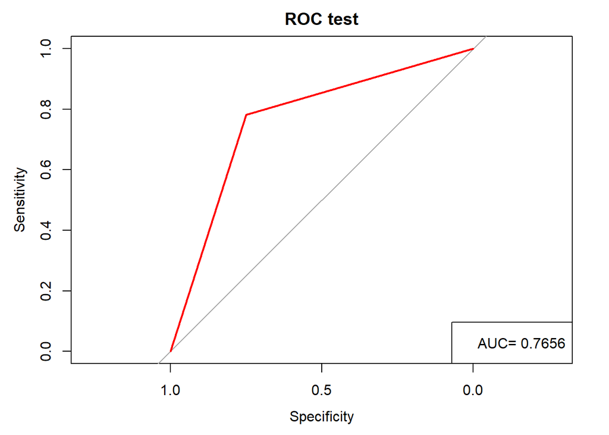

```r
roc <- roc(as.numeric(test$output),as.numeric(predicted_model))
plot(roc,col="red",lwd=2,main="ROC test")
legend("bottomright",legend=paste("AUC=",round(auc(roc),4)))
```

En aquest cas, obtnim una performance de 0.7656 que ens informa d’un valor diagnòstic positiu.

## 5.5 Random Forest

A continuació, per comparar amb el model anterior en concepte de rendiment, mostrarem un exemple d’aplicació d’un model random forest al conjunt de dades sobre el dataset original, mitjançant una validació creuada amb 4 folds on es divideixen les dades en entrenament i test per només aplicar l’entrenament mitjançant validació creuada al primer subconjunt. Posteriorment, mitjançant la funció predict() es prediu el resultat de les dades del subconjunt de test i es representen les diferents mesures de bondat del model, mitjançant la funció confusionMatrix(), especificant com a positius els casos d’atac de cor.

```r
set.seed(123)
heart_num <- heart[complete.cases(heart),c(-17,-16,-15)]
h<-holdout(heart_num$output, ratio=2/3,mode="stratified")
data_train<-heart_num[h$tr,]
data_train$output <- as.factor(data_train$output)
data_test<-heart_num[h$ts,]
data_test$output <- as.factor(data_test$output)
```

Volem analitzar quines són les variables més contributives sobre el model Random Forest:

```r
model <- randomForest(output~., data=data_train)
model$importance
```

```
##          MeanDecreaseGini
## age              8.160091
## sex              3.739620
## cp              11.036192
## trtbps           7.617683
## chol             7.097344
## fbs              1.060219
## restecg          2.479304
## thalachh        12.349974
## exng             4.913949
## oldpeak         13.652746
## slp              4.596728
## caa             11.865729
## thall            9.531293
```

Escollirem les següents variables predictores amb més pes: age+sex+cp+trtbps+chol+thalachh+exng+oldpeak+slp+caa+thall

```r
train_control<- trainControl(method="cv", number=4)
mod<-train(output~age+sex+cp+trtbps+chol+thalachh+exng+oldpeak+slp+caa+thall, data=data_train, method="rf", trControl = train_control)
pred <- predict(mod, newdata=data_test)
CrossTable(data_test$output, pred, prop.chisq  = FALSE, prop.c = FALSE, prop.r = FALSE, dnn = c('Reality', 'Prediction'))
```

```
##
##
##    Cell Contents
## |-------------------------|
## |                       N |
## |         N / Table Total |
## |-------------------------|
##
##
## Total Observations in Table:  101
##
##
##              | Prediction
##      Reality |         0 |         1 | Row Total |
## -------------|-----------|-----------|-----------|
##            0 |        37 |         9 |        46 |
##              |     0.366 |     0.089 |           |
## -------------|-----------|-----------|-----------|
##            1 |         8 |        47 |        55 |
##              |     0.079 |     0.465 |           |
## -------------|-----------|-----------|-----------|
## Column Total |        45 |        56 |       101 |
## -------------|-----------|-----------|-----------|
##
##
```

```r
confusionMatrix(pred,data_test$output, positive="1")
```

```
## Confusion Matrix and Statistics
##
##           Reference
## Prediction  0  1
##          0 37  8
##          1  9 47
##
##                Accuracy : 0.8317
##                  95% CI : (0.7442, 0.8988)
##     No Information Rate : 0.5446
##     P-Value [Acc > NIR] : 1.096e-09
##
##                   Kappa : 0.6601
##
##  Mcnemar's Test P-Value : 1
##
##             Sensitivity : 0.8545
##             Specificity : 0.8043
##          Pos Pred Value : 0.8393
##          Neg Pred Value : 0.8222
##              Prevalence : 0.5446
##          Detection Rate : 0.4653
##    Detection Prevalence : 0.5545
##       Balanced Accuracy : 0.8294
##
##        'Positive' Class : 1
##
```

Observem que el model generat ha predit correctament 84 dels 101 registres (~83,2%).

Per una banda, tenim una sensibilitat del 85.5% i, per l’altra banda, una especificitat de 80%, en conseqüència, en tenim una precisió equilibrada de 83% on s’ajusta a un bon rendiment de model. A més, fem un gràfic per assegurar-nos de la qualitat d’aquest model:

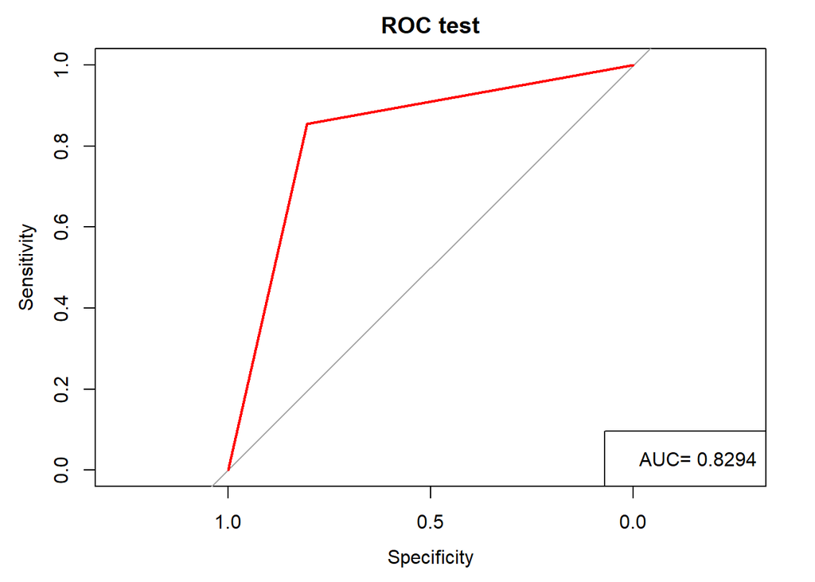

```r
roc <- roc(as.numeric(data_test$output),as.numeric(pred))
plot(roc,col="red",lwd=2,main="ROC test")
legend("bottomright",legend=paste("AUC=",round(auc(roc),4)))
```

Finalitzem amb una performance de 0.8294 que ens informa d’un valor diagnòstic positiu.

# 6 Conclusions

Finalment, emmagatzemem en un fitxer el dataset utilitzat, on s’ha realitzat una neteja i s’hi han afegit nous atributs calculats.

```r
write.csv(heart, "./dataset/HeartAttackAnalysis.csv")
```